# 第6章 微分方程

目录

6.1 微分方程模型 例1 空气冷却问题 例2 目标跟踪问题 6.3 用MATLAB解微分方程 例4 解微分方程 例6 求6.1节例2目标跟踪问题的数值解 6.6 习题 1. 污染物降解问题

## 6.1 微分方程模型

### 例1 空气冷却问题

物体在空气中的冷却速度与物体和空气的温差成正比，如果物体在20min内有100℃冷却到60℃，那么经过多长时间此物体的温度将达到30℃？

解：记温度为T、时间为t、冷却常数为k，根据牛顿冷却定律，得

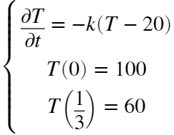

### 例2 目标跟踪问题

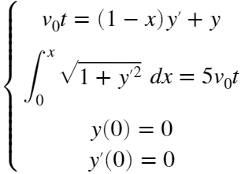

解得

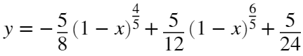

## 6.3 用MATLAB解微分方程

### 例4 解微分方程

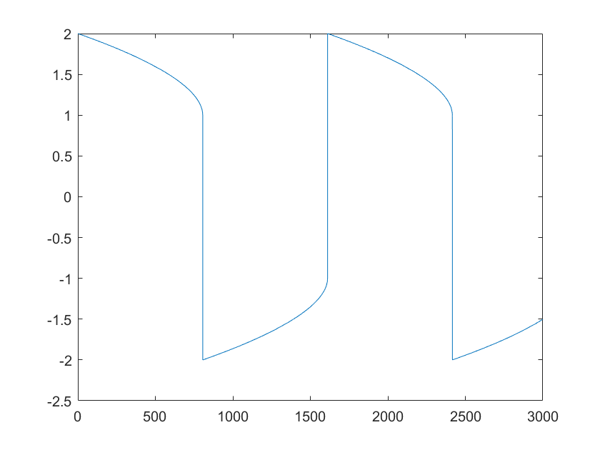

```matlab
clear T Y
[T, Y] = ode15s(@vdp1000, [0, 3000], [2, 0]);
plot(T, Y(:, 1), "-");
```

### 例6 求6.1节例2目标跟踪问题的数值解

解：（1）列方程

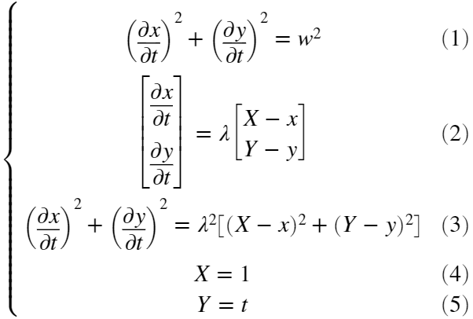

解得

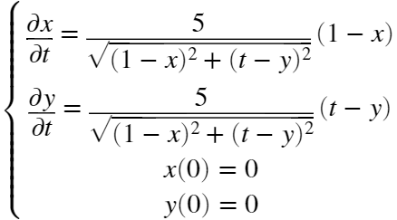

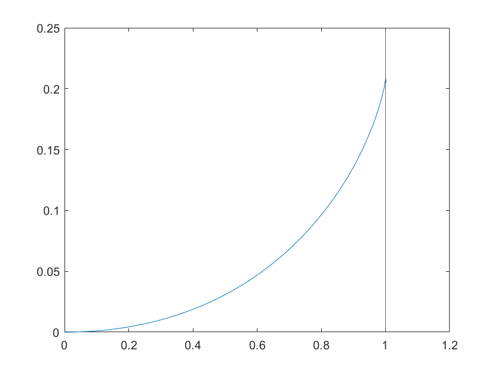

```matlab
clear t0 tf t y
t0 = 0;
tf = 0.21;
[~, y] = ode45(@eq2, [t0, tf], zeros(1, 2));
plot(y(:, 1), y(:, 2), "-");
xline(1);
```

## 6.6 习题

### 1. 污染物降解问题

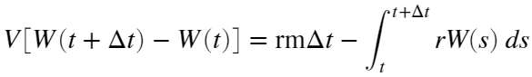

```matlab
clear t W(t) m r V W_0 equations conditions origin
syms t W(t) m r V W_0
equations = (diff(W, t) == (r * m - r * W) / V);
conditions = (W(0) == W_0);
origin = dsolve(equations, conditions)
```

```matlab
m = 0;
r = 3.663959132e10;
V = 4781e9;
W_0 = 1;
vpa(solve(eval(origin) == 0.05, t))
```

ans =

390.90490597376103428693494274317